# Documento Colaborativo: Ejemplos Prácticos de Modelos Bayesianos con INLA en R

Diciembre de 2023

# Introducción

En este documento, exploraremos diferentes modelos ajustados tanto en el enfoque frecuentista como en el bayesiano utilizando INLA y MCMC (JAGS, WinBUGS…). Empecemos cargando los paquetes necesarios para realizar los ejemplos.

```r
# Cargar paquetes
library(INLA)
library(jagsUI)
library(R2WinBUGS)
library(sf)
library(vctrs)
library(tidyr)
library(tidyverse)
library(gridExtra)
library(flextable)
library(fields)
library(dplyr)
library(glmm)
```

# Datos Bernoulli

Para contextualizar nuestro análisis, consideramos un conjunto de datos obtenido de un estudio en Galicia sobre *Fasciola hepatica* en granjas de vacuno. El objetivo es analizar la presencia o ausencia del parásito en 200 granjas de vacuno en Galicia.

```r
# Cargar y explorar datos
datos <- read.csv("datos/granjas.csv", header = TRUE, row.names = 1)
colnames(datos) <- c("InfFasc", "Aptitud", "Permeabilidad", "Temperatura", "Edad")
datos$InfFasc <- as.factor(datos$InfFasc)
datos$Aptitud <- as.factor(datos$Aptitud)
datos$Permeabilidad <- as.factor(datos$Permeabilidad)

# Resumen de los datos
summary(datos)
```

```
##  InfFasc     Aptitud    Permeabilidad  Temperatura         Edad
##  0:155      C    : 50   1:97          Min.   :10.00   Min.   : 2.00
##  1: 45      L    :150   2:76          1st Qu.:10.90   1st Qu.: 6.00
##                         3:27          Median :11.55   Median : 8.00
##                                       Mean   :11.50   Mean   : 8.43
##                                       3rd Qu.:12.10   3rd Qu.:10.00
##                                       Max.   :13.20   Max.   :20.00
```

```r
# Convertir InfFasc a numérico para el modelo
datos$InfFasc <- as.numeric(as.character(datos$InfFasc))
```

- **Variable respuesta**: $Y_i$ es la variable indicadora de presencia (1) o ausencia (0) de parásito en las $i = 1, ..., 200$ granjas analizadas.
- **Variables explicativas**: La aptitud productiva de la granja (categórica nominal con dos niveles, cárnica (C) o lechera (L)), la temperatura media anual de la granja (variable cuantitativa y continua), la edad media de las vacas de la granja (variable cuantitativa y continua) y la permeabilidad del suelo (variable categórica y ordinal con tres niveles, baja (1), media (2) y alta (3)).
- Como la presencia del parásito es una variable indicadora binaria de tipo categórica nominal, se distribuye Bernoulli de parámetro $\pi_i$ (probabilidad de que el ganado de una granja $i$ esté infectado):

$$Y_i \sim Ber(\pi_i), \quad i = 1, ..., 200$$

- Utilizamos la transformación logit para relacionar el predictor lineal con la respuesta media:

$$log \Big( \frac{\pi_i}{1 - \pi_i} \Big) = logit(\pi_i) = \beta_0 +
\beta_1 X^{(1)}_i + \beta_2 (X^{(1)}_i)^2 + \beta_3 X^{(2)}_i +
\gamma_{j(i)} + \delta_{k(i)}$$

- El predictor lineal consiste de un intercepto $\beta_0$, una covariable edad $X^{(1)}_i$ , la temperatura del suelo $X^{(2)}_i$, un factor fijo aptitud de la granja $\gamma_{j(i)}$ con dos niveles (cárnica γ1 = 0 o lechera γ1) y otra variable categórica ordinal $\delta_{k(i)}$ (permeabilidad baja $\delta_{1}$ = 0, media $\delta_{2}$ y alta $\delta_{3}$).

> ℹ️ El modelo final utilizado fue obtenido después de la selección de variables realizada en la Tarea 2 de la asignatura de GLM. Más adelante, introduciremos un ejemplo para comparar modelos en INLA.

## Frecuentista

```r
# Ajustar modelo frecuentista
mod_freq <- glm(InfFasc ~ Edad + I(Edad^2) + Temperatura + Aptitud + Permeabilidad,
                data = datos, family = binomial(link = logit))

# Resumen del modelo
summary(mod_freq)
```

```
##
## Call:
## glm(formula = InfFasc ~ Edad + I(Edad^2) + Temperatura + Aptitud +
##     Permeabilidad, family = binomial(link = logit), data = datos)
##
## Coefficients:
##                 Estimate Std. Error z value Pr(>|z|)
## (Intercept)      3.36850    3.14232   1.072  0.28373
## Edad             1.03492    0.33693   3.072  0.00213 **
## I(Edad^2)       -0.04615    0.01603  -2.879  0.00398 **
## Temperatura     -0.72497    0.26767  -2.708  0.00676 **
## Aptitud   L     -1.43723    0.44592  -3.223  0.00127 **
## Permeabilidad2  -0.74063    0.42314  -1.750  0.08006 .
## Permeabilidad3  -1.40328    0.67376  -2.083  0.03727 *
## ---
## Signif. codes:  0 '***' 0.001 '**' 0.01 '*' 0.05 '.' 0.1 ' ' 1
##
## (Dispersion parameter for binomial family taken to be 1)
##
##     Null deviance: 213.27  on 199  degrees of freedom
## Residual deviance: 173.57  on 193  degrees of freedom
## AIC: 187.57
##
## Number of Fisher Scoring iterations: 5
```

## Bayesiano con INLA

- Priors de $\beta_0$ y $\beta_j$ en términos de precisión en lugar de sd:

$$\beta_0 \sim N(0, \tau_{\beta_0} = 0), \quad \beta_j \sim N(0,
\tau_{\beta_j} = 0.001), \quad j = 1,2,3$$

```r
# Ajustar modelo bayesiano con INLA
mod_inla <- inla(InfFasc ~ 1 + Edad + I(Edad^2) + Temperatura + Aptitud + Permeabilidad,
                 data=datos, family = "binomial",
                 control.family = list(link = "logit"))

# Resumen del modelo
summary(mod_inla)
```

```
##
## Call:
##    c("inla.core(formula = formula, family = family, contrasts = contrasts,
##    ", " data = data, quantiles = quantiles, E = E, offset = offset, ", "
##    scale = scale, weights = weights, Ntrials = Ntrials, strata = strata,
##    ", " lp.scale = lp.scale, link.covariates = link.covariates, verbose =
##    verbose, ", " lincomb = lincomb, selection = selection, control.compute
##    = control.compute, ", " control.predictor = control.predictor,
##    control.family = control.family, ", " control.inla = control.inla,
##    control.fixed = control.fixed, ", " control.mode = control.mode,
##    control.expert = control.expert, ", " control.hazard = control.hazard,
##    control.lincomb = control.lincomb, ", " control.update =
##    control.update, control.lp.scale = control.lp.scale, ", "
##    control.pardiso = control.pardiso, only.hyperparam = only.hyperparam,
##    ", " inla.call = inla.call, inla.arg = inla.arg, num.threads =
##    num.threads, ", " keep = keep, working.directory = working.directory,
##    silent = silent, ", " inla.mode = inla.mode, safe = FALSE, debug =
##    debug, .parent.frame = .parent.frame)" )
## Time used:
##     Pre = 1.18, Running = 0.463, Post = 0.288, Total = 1.93
## Fixed effects:
##                  mean    sd 0.025quant 0.5quant 0.975quant   mode kld
## (Intercept)     3.479 3.142     -2.679    3.479      9.637  3.479   0
## Edad            1.122 0.337      0.462    1.122      1.782  1.122   0
## I(Edad^2)      -0.050 0.016     -0.081   -0.050     -0.019 -0.050   0
## Temperatura    -0.769 0.268     -1.293   -0.769     -0.244 -0.769   0
## Aptitud   L    -1.499 0.446     -2.373   -1.499     -0.625 -1.499   0
## Permeabilidad2 -0.788 0.423     -1.617   -0.788      0.041 -0.788   0
## Permeabilidad3 -1.531 0.674     -2.851   -1.531     -0.211 -1.531   0
##
## Marginal log-Likelihood:  -118.76
##  is computed
## Posterior summaries for the linear predictor and the fitted values are computed
## (Posterior marginals needs also 'control.compute=list(return.marginals.predictor=TRUE)')
```

## Bayesiano con JAGS

```r
cat(file="modelos/modelo_granjas.txt", "model{
    # Verosimilitud
    for (i in 1:n) {
        y[i] ~ dbern(p[i])
        logit(p[i]) <- beta0 +
                        beta1 * edad[i] +
                        beta2* edad[i]^2 +
                        beta3 * temperatura[i] +
                        gamma[aptitud[i]] +
                        delta[permeabilidad[i]]
    }

    # Distributiones previas
    beta0 ~ dnorm(0, 0.001) # En INLA tau = 0
    beta1 ~ dnorm(0, 0.001)
    beta2 ~ dnorm(0, 0.001)
    beta3 ~ dnorm(0, 0.001)
    gamma[1] <- 0 # Corner constrain
    gamma[2] ~ dnorm(0, 0.001)
    delta[1] <- 0 # Corner constrain
    delta[2] ~ dnorm(0, 0.001)
    delta[3] ~ dnorm(0, 0.001)
}")

datos.granjas <- list(
  y = datos$InfFasc, edad = datos$Edad,
  temperatura = datos$Temperatura,
  aptitud = as.numeric(datos$Aptitud),
  permeabilidad = as.numeric(datos$Permeabilidad),
  n = nrow(datos)
)

iniciales.granjas <- function(){
  list(beta0 = rnorm(1), beta1 = rnorm(1),
       beta2 = rnorm(1), beta3 = rnorm(1),
       gamma = c(NA, rnorm(1)),
       delta = c(NA, rnorm(1), rnorm(1)))
}

parametros.granjas <- c("beta0", "beta1", "beta2",
                        "beta3", "gamma", "delta")

set.seed(123)
mod_jags <- jags(data = datos.granjas,
                 inits = iniciales.granjas,
                 parameters = parametros.granjas,
                 model = "modelos/modelo_granjas.txt",
                 n.iter = 50000, n.burnin = 1000,
                 n.chains = 3)
save(mod_jags, file = "modelos/mcmc_granjas.RData")
```

```r
load("modelos/mcmc_granjas.RData")
# Resumen de los resultados
mod_jags$summary
```

```
##                  mean         sd         2.5%          25%         50%
## beta0      3.34510235 3.25229969  -2.83079145   1.13655940   3.3187502
## beta1      1.11597934 0.35434509   0.46559789   0.86594063   1.1065037
## beta2     -0.05002787 0.01691909  -0.08525765  -0.06098842  -0.0495856
## beta3     -0.75523198 0.27221681  -1.32123020  -0.93502706  -0.7464688
## gamma[1]   0.00000000 0.00000000   0.00000000   0.00000000   0.0000000
## gamma[2]  -1.49419037 0.45900160  -2.41213304  -1.79820931  -1.4899932
## delta[1]   0.00000000 0.00000000   0.00000000   0.00000000   0.0000000
## delta[2]  -0.78685366 0.43459186  -1.65756723  -1.07604283  -0.7795921
## delta[3]  -1.52812527 0.70753729  -2.99567342  -1.98715236  -1.5013046
## deviance 180.81208899 3.83644437 175.34492120 177.98158418 180.1517880
##                  75%        97.5%     Rhat n.eff overlap0         f
## beta0      5.3821220  10.15276767 1.004746   673        1 0.8482109
## beta1      1.3447855   1.85322195 1.006242   334        0 0.9996122
## beta2     -0.0381018  -0.01909445 1.005524   377        0 0.9991020
## beta3     -0.5722624  -0.23115053 1.005995 16748        0 0.9989116
## gamma[1]   0.0000000   0.00000000       NA     1        0 1.0000000
## gamma[2]  -1.1847668  -0.60549349 1.000663  3046        0 0.9995646
## delta[1]   0.0000000   0.00000000       NA     1        0 1.0000000
## delta[2]  -0.4904320   0.04403366 1.000056 32155        1 0.9678980
## delta[3]  -1.0393940  -0.22130310 1.000227 45775        0 0.9897483
## deviance 182.9274944 190.04336567 1.000932  3516        0 1.0000000
```

**Comparación**

Hemos realizado inferencia sobre el modelo mediante los enfoques Clásico y Bayesiano. Además, dentro de la inferencia Bayesiana, hemos utilizado un método de simulación asintóticamente exacto como MCMC y una aproximación numérica que es INLA. A continuación, compararemos los resultados de los modelos para observar que los resultados alcanzados son prácticamente idénticos.

> ⚠️ **Ojo**: Al comparar modelos en WinBUGS/JAGS con INLA porque no siempre las previas son las mismas. Mientras que en WinBUGS definimos las previas explicitament, en INL,A si ponemos nada, utiliza unas por defecto que debemos conocer (arriba las hemos definido).

Observamos que las distribuciones a posteriori de los parámetros obtenidas con JAGS y con INLA son prácticamente idénticas.

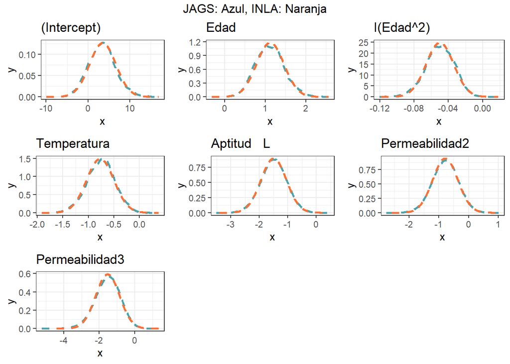

```r
# Visualización de resultados
jags_list <- list(mod_jags$sims.list$beta0,
                  mod_jags$sims.list$beta1,
                  mod_jags$sims.list$beta2,
                  mod_jags$sims.list$beta3,
                  mod_jags$sims.list$gamma[,2],
                  mod_jags$sims.list$delta[,2],
                  mod_jags$sims.list$delta[,3])
plist <- list()
for (i in 1:length(mod_inla$summary.fixed)){
  pgg <- ggplot() +
    geom_density(data = data.frame(x = jags_list[[i]]), aes(x), linewidth=1, color = "#4FA3AB", linetype = "dashed") +
    geom_line(data = data.frame(inla.smarginal(mod_inla$marginals.fixed[[i]])), aes(x, y), linewidth = 1, color = "#F6733A", linetype = "dashed") +
    ggtitle(names(mod_inla$marginals.fixed)[i]) +
    theme_bw()

  plist[[i]] <- pgg
}

n <- length(plist)
nCol <- ceiling(sqrt(n))
do.call("grid.arrange", c(plist, ncol=nCol, top = "JAGS: Azul, INLA: Naranja"))
```

Si observamos las estimaciones de los parámetros y las comparamos con la inferencia frecuentista, vemos que tenemos resultados muy similares, pero con la ventaja en el enfoque bayesiano de que tenemos una distribución para cada uno de ellos.

```r
# Comparación de resultados
params <- cbind(cbind(summary(mod_freq)$coefficients[,1], confint(mod_freq)),
                mod_jags$summary[c(1:4, 6, 8, 9), c(1,3,7)],
                mod_inla$summary.fixed[, c(1, 3, 5)])
colnames(params) <- paste0(rep(c("Frecuentista_", "JAGS_", "INLA_"), each = 3), c("est/mean", "2.5%", "97.5%"))

header_df <- tibble(key = colnames(params)) %>%
  separate(col = key, into = c("Group1", "Group2"), sep = "_", remove = FALSE, fill = "left")

params %>%
  mutate(across(where(is.numeric), round, 2)) %>%
  rownames_to_column("Coefficients") %>%
  flextable() %>%
  set_header_df(mapping = header_df, key = "key") %>%
  merge_h(part = "header") %>%
  theme_booktabs() |>
  add_footer_lines("Nota: En el enfoque frecuentista, se presentan intervalos de confianza, mientras que en el enfoque bayesiano, se presentan intervalos de credibilidad")
```

|  | Frecuentista est/mean | Frecuentista 2.5% | Frecuentista 97.5% | JAGS est/mean | JAGS 2.5% | JAGS 97.5% | INLA est/mean | INLA 2.5% | INLA 97.5% |
| --- | --- | --- | --- | --- | --- | --- | --- | --- | --- |
| (Intercept) | 3.37 | -2.76 | 9.64 | 3.35 | -2.83 | 10.15 | 3.48 | -2.68 | 9.64 |
| Edad | 1.03 | 0.42 | 1.75 | 1.12 | 0.47 | 1.85 | 1.12 | 0.46 | 1.78 |
| I(Edad^2) | -0.05 | -0.08 | -0.02 | -0.05 | -0.09 | -0.02 | -0.05 | -0.08 | -0.02 |
| Temperatura | -0.72 | -1.27 | -0.22 | -0.76 | -1.32 | -0.23 | -0.77 | -1.29 | -0.24 |
| Aptitud L | -1.44 | -2.33 | -0.57 | -1.49 | -2.41 | -0.61 | -1.50 | -2.37 | -0.63 |
| Permeabilidad2 | -0.74 | -1.60 | 0.07 | -0.79 | -1.66 | 0.04 | -0.79 | -1.62 | 0.04 |
| Permeabilidad3 | -1.40 | -2.84 | -0.16 | -1.53 | -3.00 | -0.22 | -1.53 | -2.85 | -0.21 |

Nota: En el enfoque frecuentista, se presentan intervalos de confianza, mientras que en el enfoque bayesiano, se presentan intervalos de credibilidad

# Modelo Poisson con Offset

En este ejemplo, exploraremos un modelo Poisson con offset utilizando un conjunto de datos que registra el número de quejas dirigidas al personal sanitario en un servicio de urgencias. El objetivo principal es estimar un modelo que explique la relación entre las quejas y las variables analizadas.

Las variables explicativas que consideraremos son las siguientes:

- **Número de consultas**: Una variable cuantitativa y discreta que representa la cantidad de consultas realizadas.
- **Residente**: Una variable categórica nominal con dos niveles, sí y no, que indica si el personal sanitario ha sido residente en el servicio de urgencias.
- **Sexo**: Una variable categórica ordinal dicotómica, clasificando al personal sanitario como hombre (H) o mujer (M).
- **Ingresos**: Una variable cuantitativa y continua que representa los ingresos asociados al personal sanitario.
- **Horas**: El número de horas de trabajo realizadas, una variable cuantitativa y continua.

Consideramos un modelo donde $\mu_i$ es el número medio de quejas por médico y $\lambda_i / Z_i$ representa la tasa del número de quejas $\lambda_i$ corregido por las consultas realizadas $Z_i$ (*offset*).

$$\begin{align*}
Y_i \sim & Po(\mu_i), \quad i = 1, ..., 44, \\
log(\mu_i) = & log(Z_i) + log(\lambda_i) = log(Z_i) + \beta_0 +
\beta_1 horas + \beta_2 ingresos \\
& + \beta_3 residentes + \beta_4 sexo
\end{align*}$$

Comenzamos cargando el conjunto de datos:

```r
datos <- read.table("datos/quejas.dat", header = T, sep="", stringsAsFactors = T)
```

Una parte crucial del análisis estadístico es la selección del modelo adecuado. En este caso, utilizaremos el enfoque bayesiano implementado en el paquete `INLA.` Para realizar la selección de modelos de manera eficiente en `INLA`, aprovechamos la opción `control.compute` al llamar a la función `inla()`. Esta opción nos permite calcular diversos criterios, como `cpo`, `dic`, `waic`… Puedes obtener más detalles sobre estos criterios y otras opciones [aquí](https://becarioprecario.bitbucket.io/inla-gitbook/ch-INLA.html#sec:modelassess).

Aunque existen paquetes que ofrecen funciones similares al método `step` que ya hemos empleado en el enfoque clásico, realizaremos una selección rápida de modelos en INLA. Comenzamos ajustando un modelo que incluye todas las covariables y el *offset*. La introducción del *offset* en INLA es similar a la función `glm()` y se puede especificar mediante el argumento `E` en la función `inla()` o incluirlo en la fórmula del modelo.

```r
# Modelo inicial con todas las covariables y offset
mod_inla1 <- inla(quejas ~ offset(log(consultas)) + horas + ingresos + residente + sexo,
                 data = datos, family = "poisson",
                 control.predictor = list(compute = TRUE),
                 control.compute = list(dic = TRUE, waic = TRUE, cpo = TRUE))

# Resumen del modelo inicial
mod_inla1$summary.fixed
```

```
##                      mean           sd    0.025quant      0.5quant   0.975quant
## (Intercept) -7.9567048430 0.8756877413 -9.673021e+00 -7.9567048430 -6.240388408
## horas        0.0007099344 0.0003505283  2.291155e-05  0.0007099344  0.001396957
## ingresos     0.0016649543 0.0028296255 -3.881010e-03  0.0016649543  0.007210918
## residentesi -0.2151954179 0.2011616229 -6.094650e-01 -0.2151954179  0.179074118
## sexoM       -0.2056623161 0.2181560989 -6.332404e-01 -0.2056623161  0.221915781
##                      mode kld
## (Intercept) -7.9567048430   0
## horas        0.0007099344   0
## ingresos     0.0016649543   0
## residentesi -0.2151954179   0
## sexoM       -0.2056623161   0
```

En este punto, hemos ajustado un modelo inicial que incluye todas las covariables relevantes y el offset. El siguiente paso implica la evaluación de este modelo mediante criterios como el DIC, WAIC y CPO, que nos proporcionan información valiosa sobre su ajuste y complejidad. Este enfoque nos permite realizar una selección preliminar de variables antes de avanzar en el análisis.

En este resumen, observamos que las variables sexo y residente tienen intervalos de credibilidad amplios que incluyen el cero. Dado que el factor sexo parece no tener mucha importancia en presencia de otras variables, ajustaremos el modelo sin esta variable y compararemos el DIC y WAIC.

```r
mod_inla2 <- inla(quejas ~ offset(log(consultas)) + horas + ingresos + residente ,
                 data = datos, family = "poisson",
                 control.predictor = list(compute = TRUE),
                 control.compute = list(dic = TRUE, waic = TRUE, cpo = TRUE))

c(mod_inla1$dic$dic, mod_inla2$dic$dic)
```

```
## [1] 187.3909 186.1918
```

La comparación muestra que el DIC disminuye al eliminar la variable sexo, aunque la reducción es mínima. Sin embargo, el nuevo modelo es más simple y parsimonioso, manteniendo un ajuste similar.

Continuamos explorando diferentes combinaciones de variables y posibles interacciones. Ajustamos varios modelos adicionales y evaluamos utilizando los criterios DIC, WAIC y CPO.

```r
# Modelos adicionales
mod_inla3 <- inla(quejas ~ offset(log(consultas)) + ingresos + residente,
                 data = datos, family = "poisson",
                 control.predictor = list(compute = TRUE),
                 control.compute = list(dic = TRUE, waic = TRUE, cpo = TRUE))

mod_inla4 <- inla(quejas ~ offset(log(consultas)) + horas + ingresos,
                 data = datos, family = "poisson",
                 control.predictor = list(compute = TRUE),
                 control.compute = list(dic = TRUE, waic = TRUE, cpo = TRUE))

mod_inla5 <- inla(quejas ~ offset(log(consultas)) + horas + ingresos + residente + horas:residente,
                 data = datos, family = "poisson",
                 control.predictor = list(compute = TRUE),
                 control.compute = list(dic = TRUE, waic = TRUE, cpo = TRUE))

mod_inla6 <- inla(quejas ~ offset(log(consultas)) + horas + residente + horas:residente,
                 data = datos, family = "poisson",
                 control.predictor = list(compute = TRUE),
                 control.compute = list(dic = TRUE, waic = TRUE, cpo = TRUE))
```

En la siguiente tabla se resumen los valores de DIC, WAIC y CPO para los modelos ajustados. Observamos que, aunque hay pocas diferencias notables entre muchos de ellos, el modelo 6 es uno de los más simples y parsimoniosos, mostrando valores bajos en los tres criterios. Esto sugiere que el modelo 6 podría ser una elección adecuada para nuestro análisis.

```r
# Resumen de los valores de DIC, WAIC y CPO para los modelos ajustados
d <- data.frame(Modelo = c("log(E)+H+I+R+S", "log(E)+H+I+R", "log(E)+I+R", "log(E)+H+I", "log(E)+H+I+R+H:R", "log(E)+H+R+H:R"),
  DIC = c(mod_inla1$dic$dic, mod_inla2$dic$dic, mod_inla3$dic$dic, mod_inla4$dic$dic, mod_inla5$dic$dic, mod_inla6$dic$dic),
  WAIC = c(mod_inla1$waic$waic, mod_inla2$waic$waic, mod_inla3$waic$waic, mod_inla4$waic$waic, mod_inla5$waic$waic, mod_inla6$waic$waic),
  CPO = c(-sum(log(mod_inla1$cpo$cpo)), -sum(log(mod_inla2$cpo$cpo)), -sum(log(mod_inla3$cpo$cpo)), -sum(log(mod_inla4$cpo$cpo)), -sum(log(mod_inla5$cpo$cpo)), -sum(log(mod_inla6$cpo$cpo)))
)

knitr::kable(d, booktabs = TRUE,
  caption = "Resumen de los valores de DIC, WAIC y CPO para los modelos ajustados.")
```

Resumen de los valores de DIC, WAIC y CPO para los modelos ajustados.

| Modelo | DIC | WAIC | CPO |
| --- | --- | --- | --- |
| log(E)+H+I+R+S | 187.3909 | 190.0362 | 95.33936 |
| log(E)+H+I+R | 186.1918 | 188.2662 | 94.38795 |
| log(E)+I+R | 187.8855 | 189.8107 | 95.12106 |
| log(E)+H+I | 185.9528 | 186.9175 | 93.49992 |
| log(E)+H+I+R+H:R | 183.0822 | 185.0872 | 92.88466 |
| log(E)+H+R+H:R | 182.3393 | 183.9211 | 92.07505 |

Seleccionar el modelo adecuado va más allá de simplemente comparar criterios. Es esencial llevar a cabo una validación adicional, como el análisis de residuos, para asegurar la idoneidad del modelo elegido.

A continuación, presentamos el modelo final y el código para ajustarlo tanto en el enfoque clásico como en los enfoques bayesianos con JAGS e INLA:

$$\begin{align*}
Y_i \sim & Po(\mu_i), \quad i = 1, ..., 44, \\
log(\mu_i) = & log(Z_i) + log(\lambda_i) = log(Z_i) + \beta_0 +
\beta_1 horas + \beta_2 residentes \\
& + \beta_3 horas:residentes
\end{align*}$$

## Frecuentista

```r
mod_freq <- glm(quejas ~ offset(log(consultas)) + horas + residente + horas:residente
                ,data = datos, family = poisson())
```

## Bayesiana en INLA

```r
mod_inla <- inla(quejas ~ offset(log(consultas)) + horas + residente + horas:residente,
                 data = datos, family = "poisson")
```

## Bayesiano con JAGS

```r
cat(file="modelos/modelo_quejas.txt", "model{
    # Verosimilitud
    for (i in 1:n) {
        y[i] ~ dpois(mu[i])
        log(mu[i]) = beta0 + beta1 * horas[i] + beta2[residente[i]] + beta3[residente[i]]*horas[i]
    }

    # Distributiones previas
    beta0 ~ dnorm(0, 0.001)
    beta1 ~ dnorm(0, 0.001)
    beta2[1] <- 0 # Corner constrain
    beta2[2] ~ dnorm(0, 0.001)
    beta3[1] <- 0 # Corner constrain
    beta3[2] ~ dnorm(0, 0.001)
}")

datos.quejas <- list(
  y = datos$quejas, horas = datos$horas,
  residente = as.numeric(datos$residente),
  E = datos$consultas,
  n = nrow(datos)
)

iniciales.quejas <- function(){
  list(beta0 = rnorm(1), beta1 = rnorm(1),
       beta2 = c(NA, rnorm(1)),
       beta3 = c(NA, rnorm(1)))
}

parametros.quejas <- c("beta0", "beta1",
                        "beta3", "beta4")

set.seed(123)
mod_jags <- jags(data = datos.quejas,
                 inits = iniciales.quejas,
                 parameters = parametros.quejas,
                 model = "modelos/modelo_quejas.txt",
                 n.iter = 10000, n.burnin = 1000,
                 n.chains = 3)
```

# Simulacion de datos espaciales I

En este ejemplo, abordaremos la simulación de datos espaciales, asumiendo que las realizaciones provienen de un campo espacial con cierta dependencia espacial. La idea fundamental es que las observaciones cercanas en el espacio serán más similares entre sí. La similitud entre las localizaciones estará relacionada con la distancia espacial.

## Simulación de los datos

Primero, generaremos las **localizaciones de los puntos**. Hay varias maneras de hacerlo, como generar puntos aleatorios en un dominio cuadrado, asignar densidades de puntos diferentes en áreas específicas o generar puntos dentro de un polígono.

```r
n <- 200 # Número de observaciones
semilla <- 2023
```

### Puntos aleatorios en un dominio cuadrado

```r
set.seed(semilla)
coords_rand <- cbind(long = sample(1:n), lat = sample(1:n))
```

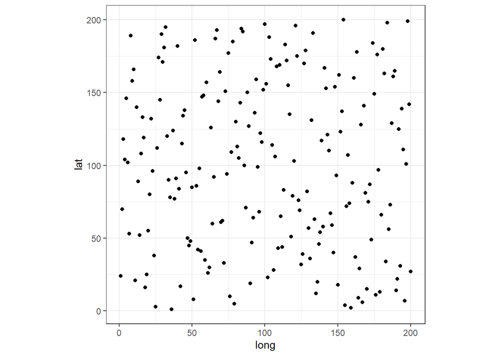

```r
ggplot(data.frame(coords_rand), aes(x = long, y = lat)) +
  geom_point() +
  theme_bw() +
  coord_fixed(ratio = 1)
```

### Puntos con mayor densidad en la esquina inferior izquierda

```r
set.seed(semilla)
coords_group <- cbind(long = sample(1:n / n - 0.5 / n)^2, lat = sample(1:n / n - 0.5 / n)^2)
```

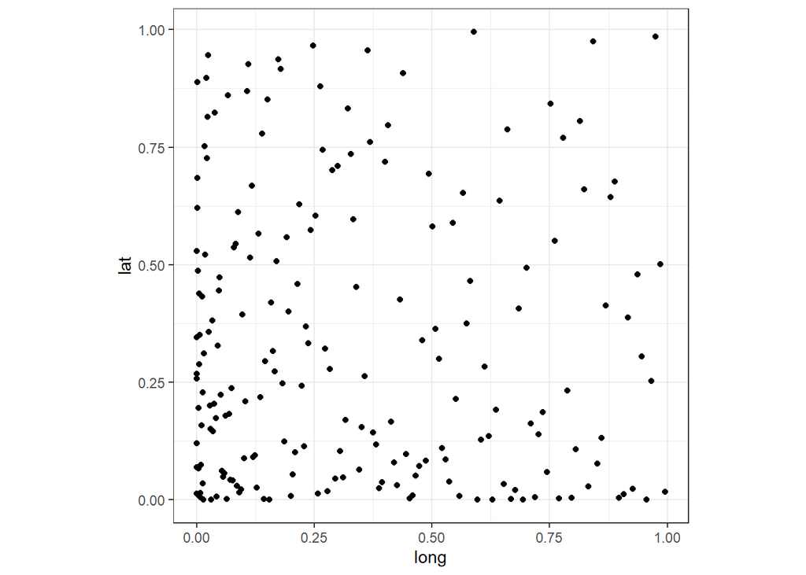

```r
ggplot(data.frame(coords_group), aes(x = long, y = lat)) +
  geom_point() +
  theme_bw() +
  coord_fixed(ratio = 1)
```

### Puntos aleatorios de un polígono

```r
# Cargar polígono
nc <- st_read(system.file("shape/nc.shp", package="sf"))
nc <- st_union(nc)

# Generar localizaciones
set.seed(semilla)
points <- st_sample(nc, size = n)
```

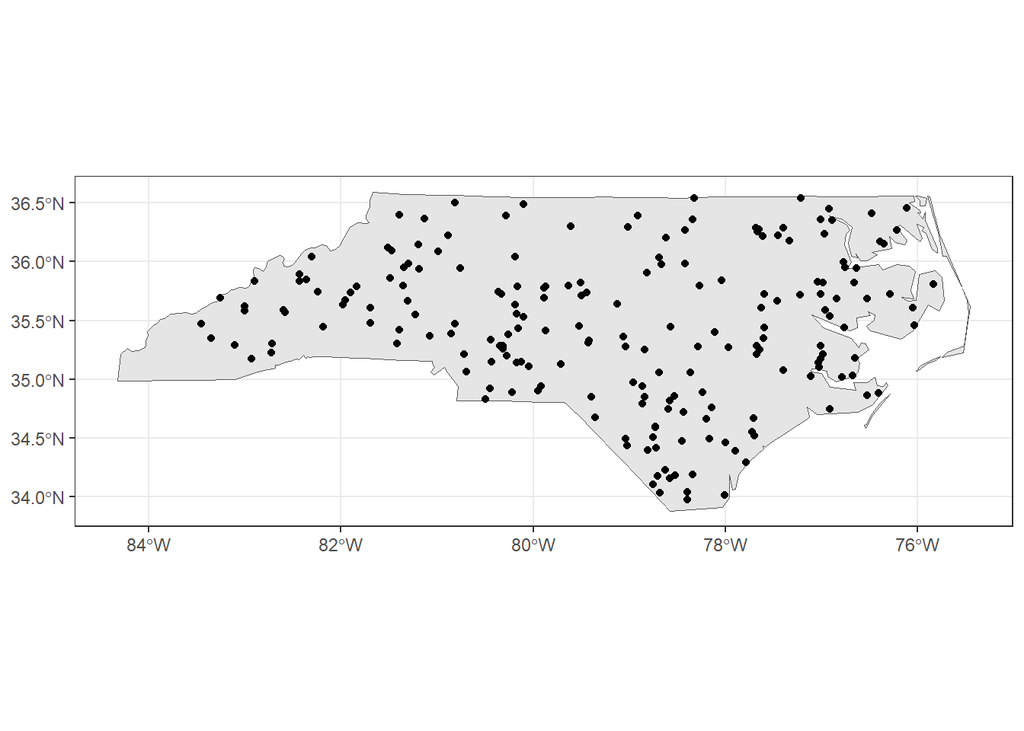

```r
ggplot() +
  geom_sf(data = nc) +
  geom_sf(data = points) +
  theme_bw()
```

La dependencia espacial entre los puntos se puede definir mediante una estructura de covarianza Matern. La función de correlación Matern tiene dos parámetros: el parámetro de escala $\kappa$ y el parámetro de suavizado $\nu$. Puedes encontrar una explicación detallada de la función de correlación Matern [aquí](https://becarioprecario.bitbucket.io/spde-gitbook/ch-intro.html#sec:matern).

$$\text{Corr}(d) = \frac{1}{2^{\nu-1}\Gamma(\nu)} (\kappa d)^{\nu}
K_{\nu}(\kappa d), \quad \alpha = \nu + \frac{d}{2},$$
donde $K_{\nu}$ es la función de Bessel modificada y $\Gamma(\cdot)$ es la función Gamma. El rango está definido como $r = \sqrt{8\nu} / \kappa$, aproximadamente la distancia donde la función de covarianza llega a ser cerca de 0.1.

Los hiperparámetros son el parámetro de precisión $\tau$ y el rango $r$, $\theta = (\tau, r)$. El campo latente tiene una varianza marginal de $\frac{1}{\tau}$ y un rango (definido como se mencionó anteriormente) de $r$. Se representan internamente como $(\text{log} \tau, \text{log} r)$.

La matriz de covarianza Matern es

$$\Sigma_{i,j} = \sigma_u Cor_M(X(s_i), X(s_j))$$

Para este ejemplo vamos a utilizar las localizaciones generadas aleatoriamente. Observamos que la posición de las localizaciones en los ejes x e y se mueve entre 0 y 200. Los parámetros que vamos a utilizar para la covarianza Matern se eligen en consecuencia. Dada las localizaciones de los puntos (entre 0 y 200) , elegiremos un rango del efecto espacial de 100. Utilizando $\nu = 1$ y a partir de esta realción $r = \sqrt{8\nu} / \kappa$, podemos obtener el valor de $\kappa = 0.02828427$. Le pondremos una varianza de $\sigma^2_u = 2$ al efecto espacial.

Ahora bien, el valor observado en las localizaciones ($_i$), a parte efecto espacial subyacente, tendrá adicionalmente un error de medición ($e_i$) que asumimos independiente y normalmente distribuido:

$$y(s_i) = x(s_i) + e_i \quad e_i \sim N(0, \sigma_e^2),$$
donde $\sigma_e^2$ es el efecto de la pepita. Por eso, tenemos una covarianza $\sigma_e^2 \mathbf{I} + \Sigma$. Definiremos un intercepto de $\beta_0 = 10$ y una semilla (error experimental) de $\sigma^2_e = 0.5$.

```r
rango <- 100
nu <- 1
kappa <- sqrt((8*nu))/rango
beta0 <- 10
sigma2e <- 0.5
sigma2u <- 2

dmat <- as.matrix(dist(coords_rand)) # Matriz distancias
```

> ⚠️ Es importante seleccionar un rango adecuado de acuerdo al tamaño y unidades de medida de la zona de estudio.

```r
mcor <- ifelse(dmat > 0, besselK(dmat * kappa, nu) * (dmat * kappa)^nu / (gamma(nu) * 2^(nu - 1)), 1)
mcor[1:5, 1:5]
```

```
##           1          2         3          4          5
## 1 1.0000000 0.35941903 0.7425567 0.16201394 0.26528369
## 2 0.3594190 1.00000000 0.2347168 0.03672258 0.06354185
## 3 0.7425567 0.23471681 1.0000000 0.23055619 0.32461764
## 4 0.1620139 0.03672258 0.2305562 1.00000000 0.68762169
## 5 0.2652837 0.06354185 0.3246176 0.68762169 1.00000000
```

```r
mcov <- sigma2e * diag(nrow(mcor)) + sigma2u * mcor
```

Finalmente, simulamos los valores de nuestra variable respuesta en las localizaciones:

```r
R <- chol(mcov) # Descomposición de Cholesky
set.seed(semilla)
y <- beta0 + drop(rnorm(n) %*% R)

datos <- data.frame(long = coords_rand[,1],
                    lat = coords_rand[,2],
                    y = y)
```

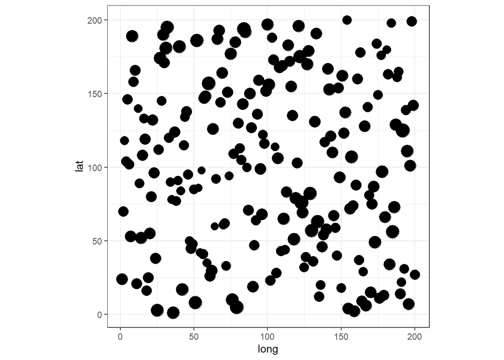

```r
ggplot(datos, aes(x = long, y = lat)) +
  geom_point(size = y/2) +
  theme_bw() +
  coord_fixed(ratio = 1)
```

## Ajuste del modelo geoestadístico con INLA

Utilizando los datos simulados, vamos a ajustar un modelo geoestadístico con INLA. Para ello, definiremos un modelo SPDE. Dadas $n$ observaciones $y_i$, $i = 1,...n$ en las localizaciones $s_i$, definimos el siguiente modelo geoestadístico sencillo:

$$\mathbf{y} | \beta_0, \mathbf{u}, \sigma_e^2 \sim N(\beta_0 +
\mathbf{Au}, \sigma_e^2),$$
donde $\beta_0$ es el intercepto, $\mathbf{A}$ es la matriz de proyección, y $\mathbf{u}$ es un campo aleatorio gaussiano espacial. La matriz de proyección $\mathbf{A}$ conecta el campo aleatorio Gaussiano con las localizaciones observadas de los datos.

Al crear un mesh, es crucial asegurarse de que cubra todo el dominio espacial de interés. Podemos definir el siguiente mesh basado en las localizaciones (las localizaciones se dispondrán en los vértices en este caso):

```r
mesh <- inla.mesh.2d(coords_rand, max.edge = c(30, 50))
```

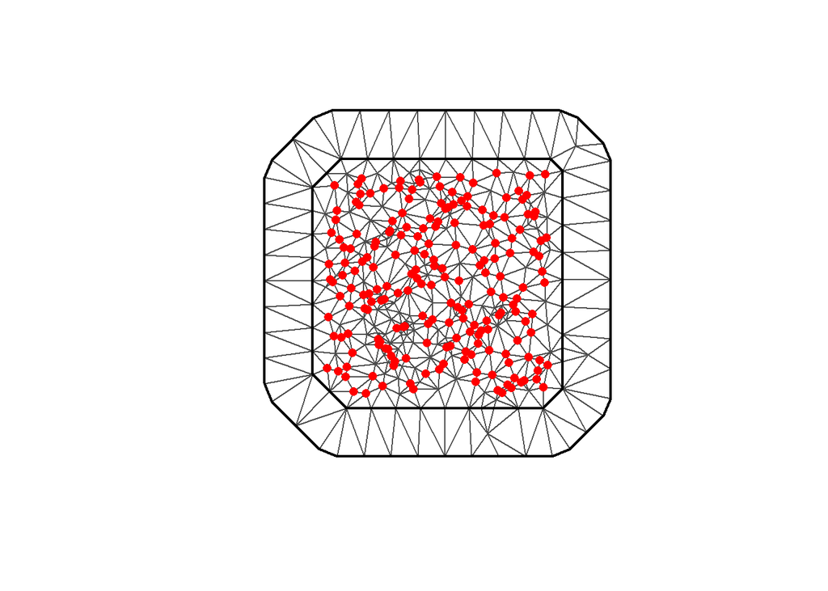

```r
plot(mesh)
points(coords_rand, col = "red", pch = 16)
```

El modelo SPDE se puede definir con la función `inla.spde2.matern()`, que utiliza los argumentos `mesh` y `alpha` relacionados con la suavización del parámetro. Esta parametrización es flexible y permite controlar los parámetros definiendo la desviación estándar marginal y el rango. También podríamos definirla utilizando las [PC-priors](https://becarioprecario.bitbucket.io/spde-gitbook/ch-INLA.html#sec:intropc) mediante la función `inla.spde2.pcmatern()`.

Una forma de definir estas priors sería representar el variograma y seleccionar priors para el rango. Como hemos simulado y conocemos el valor, no lo representaremos esta vez. Además, también es interesante realizar un análisis de sensibilidad para observar cómo varían los resultados al utilizar diferentes priors (ya os adelanto que no es particularmente robusto).

```r
spde <- inla.spde2.pcmatern(
  # Mesh and smoothness parameter
  mesh = mesh, alpha = 2,
  # P(practic.range < 50) = 0.1
  prior.range = c(50, 0.1),
  # P(sigma > 5) = 0.1
  prior.sigma = c(5, 0.1))
```

Esta parte de generar el mesh y el modelo SPDE puede ser un poco compleja. En este [enlace](https://becarioprecario.bitbucket.io/spde-gitbook/ch-intro.html#sec:spde), encontrarás una explicación más detallada.

## Matriz de proyección

El modelo SPDE se define en un mesh de dimensión $m$, mientras que la variable respuesta está definida en $n$ localizaciones. Para establecer una conexión entre los $m$ vértices del mesh y las $n$ localizaciones, empleamos una matriz de proyección $\mathbf{A}$. El valor de cualquier punto se crea proyectando dicho punto sobre un plano formado por el triángulo en el que se encuentra. El valor exacto del punto es la media ponderada de tres pesos asociados a cada vértice.

```r
A <- inla.spde.make.A(mesh, loc = coords_rand)
```

La matriz tiene una dimensión igual al número de datos en las localizaciones por el número de vértices del mesh:

```r
dim(A)
```

```
## [1] 200 403
```

## Ajuste del modelo

Para ajustar un modelo SPDE en INLA, primero debemos organizar los datos en un stack. Esta función permite ordenar los elementos importantes para definir un modelo SPDE. Los elementos clave del stack son: una lista con los vectores de datos, una lista con las matrices de proyección y una lista con los efectos.

```r
stack <- inla.stack(
  data = list(y = datos$y),
  A = list(A, 1),
  effects = list(i = 1:spde$n.spde,
                 beta0 = rep(1, nrow(datos))),
  tag = "est"
)
```

Al ajustar el modelo, debemos eliminar el intercepto de la fórmula e incluirlo como una covariable para que todos los efectos se incluyan en la matriz de proyección.

```r
res <- inla(y ~ 0 + beta0 + f(i, model = spde),
            data = inla.stack.data(stack),
            control.predictor = list(A = inla.stack.A(stack)))
```

Recordemos que al simular, definimos los siguientes parámetros:

- $\beta_0$ = 10
- $\sigma^2_e$ = 0.5
- $\sigma^2_u$ = 2
- Rango = 100
- $\nu$ = 1

Y observamos que podemos recuperar los parámetros definidos:

```r
# Intercepto
res$summary.fixed
```

```
##           mean        sd 0.025quant 0.5quant 0.975quant     mode          kld
## beta0 9.986487 0.5385074   8.911103 9.970685   11.15132 9.973486 5.176289e-05
```

```r
# Hiperparámetros
res$summary.hyperpar
```

```
##                                              mean         sd 0.025quant
## Precision for the Gaussian observations  2.544613  0.4601222  1.7578686
## Range for i                             87.057173 26.8677338 48.4071577
## Stdev for i                              1.263483  0.2363822  0.8804573
##                                          0.5quant 0.975quant      mode
## Precision for the Gaussian observations  2.504403   3.563284  2.426485
## Range for i                             82.472464 152.870860 73.326774
## Stdev for i                              1.236118   1.807067  1.173109
```

```r
# Convertimos la precisión en desviación
post.se <- inla.tmarginal(function(x) sqrt(1 / exp(x)),
                          res$internal.marginals.hyperpar[[1]])
inla.emarginal(function(x) x, post.se)
```

```
## [1] 0.6344698
```

```r
inla.hpdmarginal(0.95, post.se)
```

```
##                  low     high
## level:0.95 0.5257313 0.747312
```

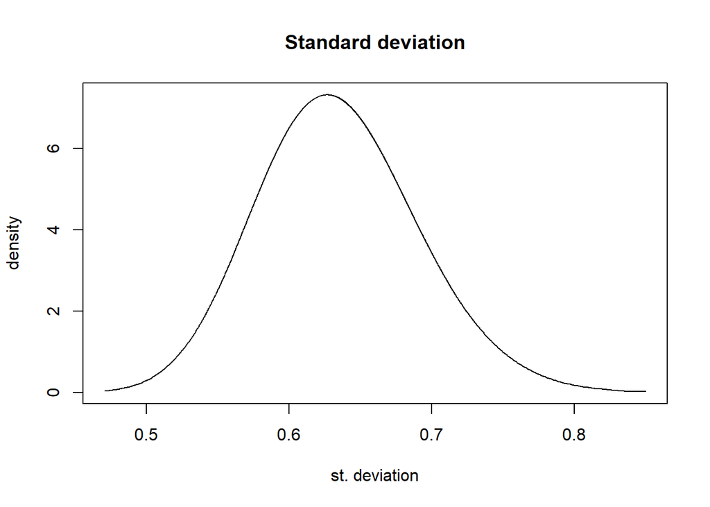

```r
plot(post.se, type = "l", xlab = "st. deviation",
     ylab = "density", main = "Standard deviation")
```

## Proyección del campo aleatorio y predicciones

Un objetivo principal al trabajar con modelos espaciales es visualizar el campo aleatorio. Utilizando la función `inla.mesh.projector()`, generaremos una matriz de proyección sobre un grid de puntos que cubre nuestro mesh.

```r
grid.projector <- inla.mesh.projector(
  mesh,
  xlim = c(0, 200), ylim = c(0, 200),
  dims = c(101, 101)
)
```

A continuación, podemos obtener la media y desviación a posteriori del efecto espacial basándonos en la idea del mesh, donde cada punto se interpola utilizando esa matriz de proyección y para cada punto (fila de la matriz), tenemos el peso de los tres vértices del triángulo del mesh donde se encuentra:

```r
prd0.m <- inla.mesh.project(grid.projector,
                            res$summary.random$i$mean)
prd0.s <- inla.mesh.project(grid.projector,
                            res$summary.random$i$sd)
```

Por otro lado, otra cantidad de interés es el valor esperado en las localizaciones que no hemos observado. Considerando que
$$\mathbf{y} \sim N(\mu = \mathbf{1}\beta_0 + \mathbf{Au}, \sigma_ e^2
\mathbf{I}),$$
vamos a querer predecir la media y desviación en diferentes localizaciones, es decir, la distribución a posteriori de $\mu$.

Para ello, debemos crear un escenario de predicción. Crearemos dos stacks, uno que represente los datos observados y otro las predicciones (con NA en la respuesta). Estos stacks se juntarán en un mismo stack.

```r
stack_pred <- inla.stack(
  data = list(y = NA),
  A = list(grid.projector$proj$A, 1),
  effects = list(i = 1:spde$n.spde,
                 beta0 = rep(1, nrow(grid.projector$proj$A))),
  tag = "pred"
)

stack_all <- inla.stack(stack, stack_pred)

res.pred <- inla(y ~ 0 + beta0 + f(i, model = spde),
                 data = inla.stack.data(stack_all),
                 control.predictor = list(A = inla.stack.A(stack_all),
                                          compute = TRUE),
                 control.mode = list(theta = res$mode$theta,
                                     restart = FALSE),
                 quantiles = NULL)
```

Obtenemos los índices de los valores predichos:

```r
igr <- inla.stack.index(stack_all, 'pred')$data
```

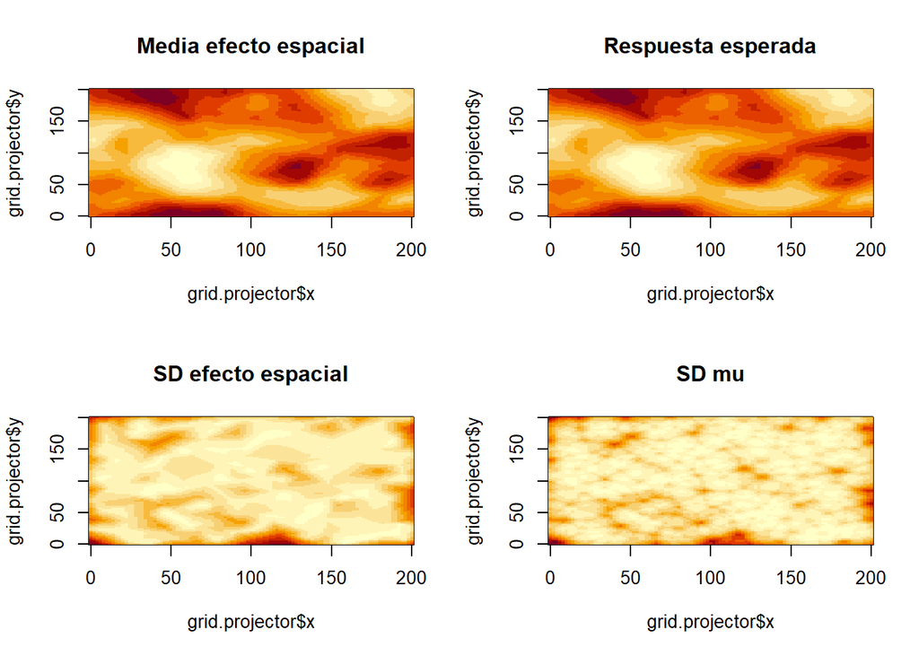

```r
par(mfrow = c(2, 2))
image(x = grid.projector$x, y = grid.projector$y, z = prd0.m, main = "Media efecto espacial")
image(x = grid.projector$x, y = grid.projector$y, z =  matrix(res.pred$summary.fitted.values$mean[igr], 101), main = "Respuesta esperada")
image(x = grid.projector$x, y = grid.projector$y, z = prd0.s, main = "SD efecto espacial")
image(x = grid.projector$x, y = grid.projector$y, z =  matrix(res.pred$summary.fitted.values$sd[igr], 101), main = "SD mu")
```

# Datos Binomiales(Práctica 7 MJB)

Vamos a analizar un banco de datos que contiene las *defunciones por cáncer de estómago* en 84 ciudades de *Missouri*, además de la población de cada una de ellas.

```r
#Cargamos los datos
load("datos/meta (1).Rdata")
datos_cancer <- cbind(N, y)
datos_cancer <- as.data.frame(datos_cancer)

#Resumen de los datos
summary(datos_cancer)
```

```
##        N                 y
##  Min.   :  305.0   Min.   : 0.000
##  1st Qu.:  446.8   1st Qu.: 0.000
##  Median :  652.0   Median : 1.000
##  Mean   : 3562.3   Mean   : 4.119
##  3rd Qu.: 1190.8   3rd Qu.: 1.250
##  Max.   :98066.0   Max.   :99.000
```

- **Variable respuesta**: $Y_i$ es la variable que nos dice el número de defunciones por cáncer respecto del total de la población. ($i = 1, ..., 84$)
- En este caso no disponemos de ninguna covariable que nos ayude a explicar la distribución de nuestro modelo.
- Deseamos estimar la tasa de mortalidad (por 100000 habitantes) para cada una de las ciudades, por lo que consideramos el siguiente modelo estadístico:

$$Y_i \sim Bin(\pi_i,n_i), \quad i = 1, ..., 84$$
- Utilizamos la transformación logit para relacionar el predictor lineal con la respuesta media:

$$log \Big( \frac{\pi_i}{1 - \pi_i} \Big) = logit(\pi_i) = a_i$$
- El predictor lineal consiste únicamente en el efecto a, el cual modelizaremos como efecto aleatorio normal, ya que al modelizarlo como efecto fijo de cada ciudad o como efecto fijo común perderíamos información relevante sobre la muestra.

## Bayesiano con INLA

```r
#Calculamos la tasa esperada para comparar los resultados
pi <- datos_cancer$y/datos_cancer$N

#Introducimos el efecto aleatorio
mod_inla_cancer <- inla(y ~ 1+f(pi, model = "iid"),
     family = "binomial",
     Ntrials = N,
     #El argumento Ntrials es necesario en la binomial

     control.compute = list(dic = TRUE, waic = TRUE, return.marginals.predictor = TRUE),
     #Estos argumentos nos servirán para la comparación de modelos
     #El argumento return.marginals nos ayudará a graficar pi
     control.predictor = list(compute = TRUE),
     data = datos_cancer)

summary(mod_inla_cancer)
```

```
##
## Call:
##    c("inla.core(formula = formula, family = family, contrasts = contrasts,
##    ", " data = data, quantiles = quantiles, E = E, offset = offset, ", "
##    scale = scale, weights = weights, Ntrials = Ntrials, strata = strata,
##    ", " lp.scale = lp.scale, link.covariates = link.covariates, verbose =
##    verbose, ", " lincomb = lincomb, selection = selection, control.compute
##    = control.compute, ", " control.predictor = control.predictor,
##    control.family = control.family, ", " control.inla = control.inla,
##    control.fixed = control.fixed, ", " control.mode = control.mode,
##    control.expert = control.expert, ", " control.hazard = control.hazard,
##    control.lincomb = control.lincomb, ", " control.update =
##    control.update, control.lp.scale = control.lp.scale, ", "
##    control.pardiso = control.pardiso, only.hyperparam = only.hyperparam,
##    ", " inla.call = inla.call, inla.arg = inla.arg, num.threads =
##    num.threads, ", " keep = keep, working.directory = working.directory,
##    silent = silent, ", " inla.mode = inla.mode, safe = FALSE, debug =
##    debug, .parent.frame = .parent.frame)" )
## Time used:
##     Pre = 0.802, Running = 0.504, Post = 0.34, Total = 1.65
## Fixed effects:
##               mean    sd 0.025quant 0.5quant 0.975quant   mode kld
## (Intercept) -6.661 0.126     -6.906   -6.662     -6.411 -6.662   0
##
## Random effects:
##   Name     Model
##     pi IID model
##
## Model hyperparameters:
##                  mean   sd 0.025quant 0.5quant 0.975quant mode
## Precision for pi 4.66 2.84       1.69     3.91      11.87 3.02
##
## Deviance Information Criterion (DIC) ...............: 200.43
## Deviance Information Criterion (DIC, saturated) ....: 67.05
## Effective number of parameters .....................: 18.33
##
## Watanabe-Akaike information criterion (WAIC) ...: 195.90
## Effective number of parameters .................: 10.89
##
## Marginal log-Likelihood:  -115.03
##  is computed
## Posterior summaries for the linear predictor and the fitted values are computed
## (Posterior marginals needs also 'control.compute=list(return.marginals.predictor=TRUE)')
```

El intercept aparece por defecto en el modelo con la transformación presente en el link (en este caso logit), los fitted values aparecen en escala original.

Ahora utilizaremos un tipo de prior distinta, muy utilizada en la modelización con INLA, llamadas en su conjunto *Penalized Complexity Priors* o PC-priors.

- Estas priors penalizan la distancia hacia un modelo base al menos que haya evidencia en su contra (*Princpio de Parsimonia*).
- Se definen estableciendo probabilidades sobre los parámetros del modelo en la escala adecuada.

**Ejemplo**

Para la precisión($\tau$) se utilizan los parámetros u y $\alpha$, tal que:

$$Prob(\sigma >u)= \alpha$$
En este caso utilizaremos una PC prior para la precisión de nuestro efecto aleatorio.

```r
#Probando con diferentes priors
mod_inla_cancer_2 <- inla(y ~ 0+f(pi, model = "iid", hyper = list(
prec = list(
prior = "pc.prec",
param = c(5, 0.01)))),
     family = "binomial",
     Ntrials = N,
#El argumento Ntrials es necesario en la binomial

     control.compute = list(dic = TRUE, waic = TRUE, return.marginals.predictor = TRUE),
#Estos argumentos nos servirán para la comparación de modelos
     #El argumento return.marginals nos ayudará a graficar pi
     control.predictor = list(compute = TRUE),
     data = datos_cancer)

summary(mod_inla_cancer_2)
```

```
##
## Call:
##    c("inla.core(formula = formula, family = family, contrasts = contrasts,
##    ", " data = data, quantiles = quantiles, E = E, offset = offset, ", "
##    scale = scale, weights = weights, Ntrials = Ntrials, strata = strata,
##    ", " lp.scale = lp.scale, link.covariates = link.covariates, verbose =
##    verbose, ", " lincomb = lincomb, selection = selection, control.compute
##    = control.compute, ", " control.predictor = control.predictor,
##    control.family = control.family, ", " control.inla = control.inla,
##    control.fixed = control.fixed, ", " control.mode = control.mode,
##    control.expert = control.expert, ", " control.hazard = control.hazard,
##    control.lincomb = control.lincomb, ", " control.update =
##    control.update, control.lp.scale = control.lp.scale, ", "
##    control.pardiso = control.pardiso, only.hyperparam = only.hyperparam,
##    ", " inla.call = inla.call, inla.arg = inla.arg, num.threads =
##    num.threads, ", " keep = keep, working.directory = working.directory,
##    silent = silent, ", " inla.mode = inla.mode, safe = FALSE, debug =
##    debug, .parent.frame = .parent.frame)" )
## Time used:
##     Pre = 0.849, Running = 0.5, Post = 0.281, Total = 1.63
## Random effects:
##   Name     Model
##     pi IID model
##
## Model hyperparameters:
##                   mean    sd 0.025quant 0.5quant 0.975quant  mode
## Precision for pi 0.023 0.004      0.016    0.023      0.033 0.023
##
## Deviance Information Criterion (DIC) ...............: 239.31
## Deviance Information Criterion (DIC, saturated) ....: 105.94
## Effective number of parameters .....................: 51.89
##
## Watanabe-Akaike information criterion (WAIC) ...: 277.71
## Effective number of parameters .................: 54.74
##
## Marginal log-Likelihood:  -213.85
##  is computed
## Posterior summaries for the linear predictor and the fitted values are computed
## (Posterior marginals needs also 'control.compute=list(return.marginals.predictor=TRUE)')
```

## Bayesiano con WinBUGS

```r
datos_cancer_winb <- list(y = y, N = N, n = length(y))
p.star <- sum(y)/sum(N)
logit.p.star <- log(p.star/(1 - p.star))
mod_cancer_winb <- function() {
  for (i in 1:n) {
    y[i] ~ dbin(pi[i], N[i])
    logit(pi[i]) <- mu + theta[i]
    theta[i] ~ dnorm(0, tau)
    # Probabilidad de exceso de riesgo

    p[i] <- step(theta[i])
    # tasa por 100.000 habitantes

    tasa[i] <- pi[i] * 1e+05
  }
  #distribuciones iniciales

  mu ~ dflat()
  tau <- pow(sd.theta, -2)
  sd.theta ~ dunif(0, 100)
}
# Modelo efectos aleatorios

iniciales_cancer_winb <- function() {
  list(mu = rnorm(1, logit.p.star, 1), theta = rnorm(84, 0, 1), sd.theta = runif(1, 0, 2))
}

param <- c("pi")
set.seed(123)
resul_mod_cancer_winb <- bugs(data = datos_cancer_winb, inits = iniciales_cancer_winb, parameters = param, model = mod_cancer_winb,
                n.burnin = 1000, n.iter = 5000, bugs.directory = "C:/Users/juanv/OneDrive/Escritorio/Master Bioestadística/Modelización avanzada/Modelos jerárquicos Bayesianos/Prácticas/WinBUGS14")

save(resul_mod_cancer_winb, file = "modelos/mcmc_cancer.RData")

head(round(resul_mod_cancer_winb$summary,6))
```

```r
load("modelos/mcmc_cancer.RData")
# Resumen de los resultados
head(round(resul_mod_cancer_winb$summary, 6))
```

```
##           mean       sd     2.5%      25%      50%      75%    97.5%     Rhat
## pi[1] 0.001021 0.000095 0.000834 0.000960 0.001018 0.001087 0.001212 1.005046
## pi[2] 0.001023 0.000125 0.000789 0.000938 0.001016 0.001107 0.001273 1.000156
## pi[3] 0.001605 0.000186 0.001266 0.001478 0.001594 0.001721 0.002006 1.000818
## pi[4] 0.001229 0.000228 0.000837 0.001071 0.001205 0.001369 0.001716 1.000752
## pi[5] 0.001067 0.000225 0.000661 0.000910 0.001051 0.001205 0.001540 1.002333
## pi[6] 0.001406 0.000334 0.000900 0.001172 0.001355 0.001598 0.002151 1.003111
##       n.eff
## pi[1]   390
## pi[2]  1000
## pi[3]  1000
## pi[4]  1000
## pi[5]   710
## pi[6]  1000
```

**Comparación**

A continuación, compararemos los resultados de los modelos, en concreto, la proporción de enfermos de cáncer de las 6 primeras ciudades, a modo de muestra:

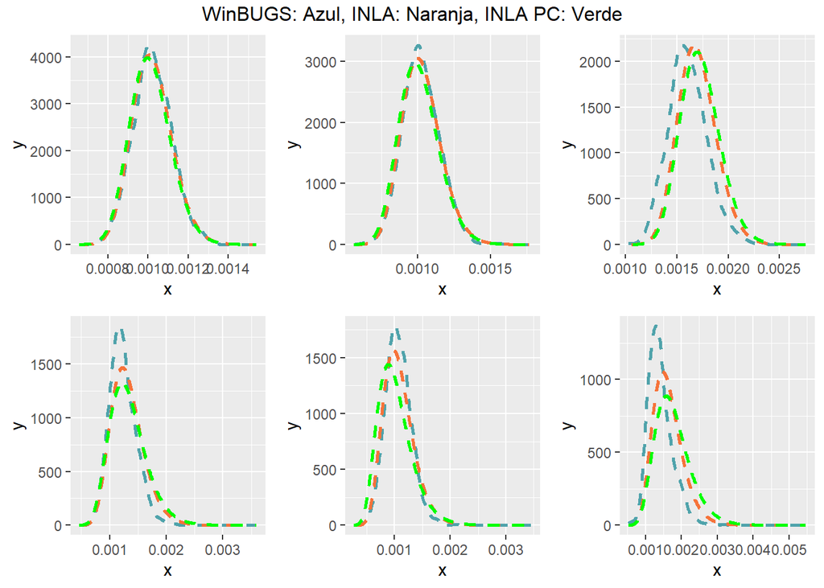

```r
# Visualización de resultados

#Extraemos las proporciones de cada ciudad

#INLA
pi_inla <- mod_inla_cancer$marginals.fitted.values
pi_inla_2 <- mod_inla_cancer_2$marginals.fitted.values

#WinBUGS
pi_winb <- resul_mod_cancer_winb$sims.list$pi
winb_cancer_list <- list()
for (i in 1:84) {
winb_cancer_list[[i]] <- pi_winb[, i]
}

#Representamos conjuntamente las distribuciones de los 3 modelos
plist_2 <- list()
for (i in 1:6){
  pgg <- ggplot() +
    geom_density(data = data.frame(x = winb_cancer_list[[i]]), aes(x), linewidth=1, color = "#4FA3AB", linetype = "dashed") +
    geom_line(data = data.frame(inla.smarginal(pi_inla[[i]])), aes(x, y), linewidth = 1, color = "#F6733A", linetype = "dashed") +
    geom_line(data = data.frame(inla.smarginal(pi_inla_2[[i]])), aes(x, y), linewidth = 1, color = "#00FF00", linetype = "dashed")
    ggtitle(names(pi_inla)[i]) +
    theme_bw()

  plist_2[[i]] <- pgg
}

n_2 <- length(plist_2)
nCol_2 <- ceiling(sqrt(n_2))
do.call("grid.arrange", c(plist_2, ncol=nCol_2, top = "WinBUGS: Azul, INLA: Naranja, INLA PC: Verde"))
```

Podría parecer en este caso que las distribuciones a posteriori de Inla y WinBUGS no son todo lo parecidas que deberían, pero a una escala tan pequeña se pueden dar estas diferencias.

Destaca que las distribuciones a posteriori de WinBUGS son más apuntadas, seguramente porque es un método exacto, frente a una aproximación como INLA.

A continuación observamos los estimadores puntuales de las distribuciones estimadas en los modelos bayesianos.

```r
params_2 <- cbind(resul_mod_cancer_winb$summary[c(1:9), c(1, 3, 7)],
          mod_inla_cancer$summary.fitted.values[c(1:9), c(1, 3, 5)],
mod_inla_cancer_2$summary.fitted.values[c(1:9), c(1, 3, 5)])
colnames(params_2) <- paste0(rep(c("WinBUGS_", "INLA 1(no PC)_", "INLA 2(PC)_"), each = 3), c("est/mean", "2.5%", "97.5%"))

header_df_2 <- tibble(key = colnames(params_2)) %>%
  separate(col = key, into = c("Group1", "Group2"), sep = "_", remove = FALSE, fill = "left")

params_2 %>%
  mutate(across(where(is.numeric), round, 6)) %>%
  rownames_to_column("Coefficients") %>%
  flextable() %>%
  set_header_df(mapping = header_df_2, key = "key") %>%
  merge_h(part = "header") %>%
  theme_booktabs()
```

|  | WinBUGS est/mean | WinBUGS 2.5% | WinBUGS 97.5% | INLA 1(no PC) est/mean | INLA 1(no PC) 2.5% | INLA 1(no PC) 97.5% | INLA 2(PC) est/mean | INLA 2(PC) 2.5% | INLA 2(PC) 97.5% |
| --- | --- | --- | --- | --- | --- | --- | --- | --- | --- |
| pi[1] | 0.001021 | 0.000834 | 0.001212 | 0.001020 | 0.000837 | 0.001229 | 0.001011 | 0.000826 | 0.001225 |
| pi[2] | 0.001023 | 0.000789 | 0.001273 | 0.001025 | 0.000787 | 0.001311 | 0.001010 | 0.000767 | 0.001306 |
| pi[3] | 0.001605 | 0.001266 | 0.002006 | 0.001698 | 0.001361 | 0.002094 | 0.001728 | 0.001379 | 0.002137 |
| pi[4] | 0.001229 | 0.000837 | 0.001716 | 0.001316 | 0.000838 | 0.001971 | 0.001331 | 0.000806 | 0.002074 |
| pi[5] | 0.001067 | 0.000661 | 0.001540 | 0.001077 | 0.000632 | 0.001707 | 0.001017 | 0.000541 | 0.001748 |
| pi[6] | 0.001406 | 0.000900 | 0.002151 | 0.001629 | 0.000970 | 0.002586 | 0.001768 | 0.000992 | 0.002921 |
| pi[7] | 0.001035 | 0.000514 | 0.001683 | 0.001051 | 0.000469 | 0.001986 | 0.000831 | 0.000237 | 0.002129 |
| pi[8] | 0.000991 | 0.000447 | 0.001621 | 0.000968 | 0.000404 | 0.001879 | 0.000630 | 0.000133 | 0.001881 |
| pi[9] | 0.000931 | 0.000400 | 0.001461 | 0.000854 | 0.000329 | 0.001700 | 0.000357 | 0.000040 | 0.001405 |

# Modelo Poisson con Random Walk (Tarea 8 MJB)

En este caso nuestro banco de datos contiene información sobre la mortalidad por enfermedades congénitas en hombres en España.

Disponemos del número de defunciones mensuales por esta causa durante el periodo 1999-2008.

```r
load("datos/congenitas (1).Rdata")

#Añadimos una variable con los ID ordenados para poder modelizar el random walk
tiempo <- seq(1, 120)
datos_mort <- as.data.frame(cbind(tiempo, mort))
```

- **Variable respuesta**: $Y_i$ es la variable que nos dice el número de defunciones mensuales por enfermedades congénitas ($i = 1, ..., 120$)
- En este caso no disponemos de ninguna covariable que nos ayude a explicar la distribución de nuestro modelo.
- Deseamos estimar el número de defunciones esperadas, por lo que planteamos el siguiente modelo:

- Utilizamos la transformación log para relacionar el predictor lineal con la respuesta media:

$$log(\lambda_i) = a_i$$
Un modelo de efectos aleatorios sería lo adecuado para la modelización, ya que las defunciones en todos los meses deberían seguir la misma distribución.

Pero, además de esto, tiene sentido que las observaciones sean dependientes entre sí, en concreto las de meses cercanos, por lo que utilizaremos Random Walk para modelizar esta dependencia.

El efecto aleatorio dependiente $a_i$ seguirá una distribución:

$$\mu_i= a_{i-1}$$

- Para el *Random Walk de primer orden*, y:

$$\mu_i= a_{i-1}+(a_{i-1}-a_{i-2})$$
- Para el *Random Walk de segundo orden*

## Bayesiano con INLA

```r
#Especificación del random walk de primer orden
mod_mort_inla_rw1 <- inla(mort ~ f(tiempo, model = "rw1"),
         family = "poisson",
         control.compute = list(dic = TRUE, waic = TRUE, return.marginals.predictor = TRUE),
         control.predictor = list(compute = TRUE),
         data = datos_mort)
summary(mod_mort_inla_rw1)
```

```
##
## Call:
##    c("inla.core(formula = formula, family = family, contrasts = contrasts,
##    ", " data = data, quantiles = quantiles, E = E, offset = offset, ", "
##    scale = scale, weights = weights, Ntrials = Ntrials, strata = strata,
##    ", " lp.scale = lp.scale, link.covariates = link.covariates, verbose =
##    verbose, ", " lincomb = lincomb, selection = selection, control.compute
##    = control.compute, ", " control.predictor = control.predictor,
##    control.family = control.family, ", " control.inla = control.inla,
##    control.fixed = control.fixed, ", " control.mode = control.mode,
##    control.expert = control.expert, ", " control.hazard = control.hazard,
##    control.lincomb = control.lincomb, ", " control.update =
##    control.update, control.lp.scale = control.lp.scale, ", "
##    control.pardiso = control.pardiso, only.hyperparam = only.hyperparam,
##    ", " inla.call = inla.call, inla.arg = inla.arg, num.threads =
##    num.threads, ", " keep = keep, working.directory = working.directory,
##    silent = silent, ", " inla.mode = inla.mode, safe = FALSE, debug =
##    debug, .parent.frame = .parent.frame)" )
## Time used:
##     Pre = 0.802, Running = 0.508, Post = 0.347, Total = 1.66
## Fixed effects:
##              mean    sd 0.025quant 0.5quant 0.975quant  mode kld
## (Intercept) 3.787 0.014       3.76    3.787      3.814 3.787   0
##
## Random effects:
##   Name     Model
##     tiempo RW1 model
##
## Model hyperparameters:
##                         mean      sd 0.025quant 0.5quant 0.975quant    mode
## Precision for tiempo 6417.09 6099.00     859.18  4597.88   22884.99 2301.51
##
## Deviance Information Criterion (DIC) ...............: 836.10
## Deviance Information Criterion (DIC, saturated) ....: 162.46
## Effective number of parameters .....................: 7.37
##
## Watanabe-Akaike information criterion (WAIC) ...: 838.74
## Effective number of parameters .................: 9.60
##
## Marginal log-Likelihood:  -425.73
##  is computed
## Posterior summaries for the linear predictor and the fitted values are computed
## (Posterior marginals needs also 'control.compute=list(return.marginals.predictor=TRUE)')
```

```r
#Especificación del random walk de segundo orden
mod_mort_inla_rw2 <- inla(mort~f(tiempo, model = "rw2"),
         family = "poisson",
         control.compute = list(dic = TRUE, waic = TRUE, return.marginals.predictor = TRUE),
         control.predictor = list(compute = TRUE),
         data = datos_mort)
summary(mod_mort_inla_rw2)
```

```
##
## Call:
##    c("inla.core(formula = formula, family = family, contrasts = contrasts,
##    ", " data = data, quantiles = quantiles, E = E, offset = offset, ", "
##    scale = scale, weights = weights, Ntrials = Ntrials, strata = strata,
##    ", " lp.scale = lp.scale, link.covariates = link.covariates, verbose =
##    verbose, ", " lincomb = lincomb, selection = selection, control.compute
##    = control.compute, ", " control.predictor = control.predictor,
##    control.family = control.family, ", " control.inla = control.inla,
##    control.fixed = control.fixed, ", " control.mode = control.mode,
##    control.expert = control.expert, ", " control.hazard = control.hazard,
##    control.lincomb = control.lincomb, ", " control.update =
##    control.update, control.lp.scale = control.lp.scale, ", "
##    control.pardiso = control.pardiso, only.hyperparam = only.hyperparam,
##    ", " inla.call = inla.call, inla.arg = inla.arg, num.threads =
##    num.threads, ", " keep = keep, working.directory = working.directory,
##    silent = silent, ", " inla.mode = inla.mode, safe = FALSE, debug =
##    debug, .parent.frame = .parent.frame)" )
## Time used:
##     Pre = 0.744, Running = 0.536, Post = 0.371, Total = 1.65
## Fixed effects:
##              mean    sd 0.025quant 0.5quant 0.975quant  mode kld
## (Intercept) 3.786 0.014      3.759    3.786      3.813 3.786   0
##
## Random effects:
##   Name     Model
##     tiempo RW2 model
##
## Model hyperparameters:
##                          mean       sd 0.025quant 0.5quant 0.975quant     mode
## Precision for tiempo 61743.93 31785.68   16834.00 56161.48  138861.67 44938.19
##
## Deviance Information Criterion (DIC) ...............: 837.07
## Deviance Information Criterion (DIC, saturated) ....: 163.43
## Effective number of parameters .....................: 8.13
##
## Watanabe-Akaike information criterion (WAIC) ...: 840.05
## Effective number of parameters .................: 10.38
##
## Marginal log-Likelihood:  -434.08
##  is computed
## Posterior summaries for the linear predictor and the fitted values are computed
## (Posterior marginals needs also 'control.compute=list(return.marginals.predictor=TRUE)')
```

## Bayesiano con WinBUGS

```r
mod_mort_winb_rw1 <- function() {
  for (i in 1:120) {
    mort[i] ~ dpois(media[i])
    log(media[i]) <- a[i]
  }
  a[1] ~ dflat()
  for (i in 2:120) {
    a[i] ~ dnorm(a[i - 1], tau.a)
  }
  tau.a <- pow(sd.a, -2)
  sd.a ~ dunif(0, 100)
}

# Llamada al modelo RW1
datos_mort <- list(mort = mort)
inits_mod_mort_winb_rw1 <- function() {
  list(a = rnorm(120), sd.a = runif(1, 0, 5))
}
param_3 <- c("media", "sd.a")
# Elevamos el número de iteraciones habituales ya que la convergencia de
# este modelo resulta problematica

resul_mod_mort_winb_rw1 <- bugs(data = datos_mort, inits = inits_mod_mort_winb_rw1, param = param_3, model.file = mod_mort_winb_rw1,
                  n.iter = 10000, n.burnin = 2000, bugs.directory = "C:/Users/juanv/OneDrive/Escritorio/Master Bioestadística/Modelización avanzada/Modelos jerárquicos Bayesianos/Prácticas/WinBUGS14")
head(round(resul_mod_mort_winb_rw1$summary, 4))

save(resul_mod_mort_winb_rw1, file = "modelos/mcmc_mort_rw1.RData")

# Modelo Random Walk de segundo orden
mod_mort_winb_rw2 <- function() {
for (i in 1:120) {
mort[i] ~ dpois(media[i])
log(media[i]) <- a[i]
}
a[1] ~ dflat()
a[2] ~ dflat()
for (i in 3:120) {
a[i] ~ dnorm(media.a[i], tau.a)
media.a[i] <- a[i - 1] + (a[i - 1] - a[i - 2])
}
tau.a <- pow(sd.a, -2)
sd.a ~ dunif(0, 100)
}
inits_mod_mort_winb_rw2 <- function() {
list(a = rnorm(120, log(mean(mort), 0.1)), sd.a = runif(1, 0, 5))
}
resul_mod_mort_winb_rw2 <- bugs(data = datos_mort, inits = inits_mod_mort_winb_rw2, param = param_3, model.file = mod_mort_winb_rw2,
n.iter = 5e+05, n.burnin = 50000,bugs.directory = "C:/Users/juanv/OneDrive/Escritorio/Master Bioestadística/Modelización avanzada/Modelos jerárquicos Bayesianos/Prácticas/WinBUGS14")
head(round(resul_mod_mort_winb_rw2$summary, 2))

save(resul_mod_mort_winb_rw2, file = "modelos/mcmc_mort_rw2.RData")
```

```r
load("modelos/mcmc_mort_rw1.RData")
# Resumen de los resultados
head(round(resul_mod_mort_winb_rw1$summary, 4))
```

```
##             mean     sd    2.5%     25%   50%     75%   97.5%   Rhat n.eff
## media[1] 53.0415 3.5196 47.2902 50.4525 52.77 55.2575 60.5692 1.0023   720
## media[2] 52.8597 3.1977 47.6525 50.5525 52.61 54.8000 59.7572 1.0009  1000
## media[3] 52.0704 2.7613 47.1902 50.1300 51.96 53.8400 57.6197 1.0040   450
## media[4] 51.5300 2.6403 46.9202 49.6600 51.32 53.2825 57.4782 1.0036   490
## media[5] 50.9857 2.4051 46.5122 49.3000 50.86 52.6875 55.7200 1.0048   500
## media[6] 50.1808 2.2553 45.8820 48.6600 50.07 51.5900 54.6692 1.0043   410
```

```r
load("modelos/mcmc_mort_rw2.RData")
# Resumen de los resultados
head(round(resul_mod_mort_winb_rw1$summary, 4))
```

```
##             mean     sd    2.5%     25%   50%     75%   97.5%   Rhat n.eff
## media[1] 53.0415 3.5196 47.2902 50.4525 52.77 55.2575 60.5692 1.0023   720
## media[2] 52.8597 3.1977 47.6525 50.5525 52.61 54.8000 59.7572 1.0009  1000
## media[3] 52.0704 2.7613 47.1902 50.1300 51.96 53.8400 57.6197 1.0040   450
## media[4] 51.5300 2.6403 46.9202 49.6600 51.32 53.2825 57.4782 1.0036   490
## media[5] 50.9857 2.4051 46.5122 49.3000 50.86 52.6875 55.7200 1.0048   500
## media[6] 50.1808 2.2553 45.8820 48.6600 50.07 51.5900 54.6692 1.0043   410
```

La convergencia de los parámetros del random walk 2 no es buena incluso con un elevado número de interacciones, pero, por ahorrarnos tiempo, tomaremos estos valores de ejemplo, ya que un modelo con más interacciones tardaría demasiado.

**Comparación**

Representamos el número de hombres afectados por enfermedades congénitas en los 6 primeros meses.

[figure not shown]

```r
# Visualización de resultados

#Extraemos las proporciones de cada ciudad

#INLA
pois_inla_1 <- mod_mort_inla_rw1$marginals.fitted.values
pois_inla_2 <- mod_mort_inla_rw2$marginals.fitted.values

#WinBUGS
pois_winb1 <- resul_mod_mort_winb_rw1$sims.list$media
pois_winb2 <- resul_mod_mort_winb_rw2$sims.list$media
winb_mort1_list <- list()
for (i in 1:120) {
winb_mort1_list[[i]] <- pois_winb1[, i]
}
winb_mort2_list <- list()
for (i in 1:120) {
winb_mort2_list[[i]] <- pois_winb2[, i]
}

#Representamos conjuntamente las distribuciones de los 3 modelos
plist_3 <- list()
for (i in 1:6){
  pgg <- ggplot() +
    geom_density(data = data.frame(x = winb_mort1_list[[i]]), aes(x), linewidth=1, color = "#4FA3AB", linetype = "dashed") +
    geom_density(data = data.frame(x = winb_mort2_list[[i]]), aes(x), linewidth=1, color = "#FF0000", linetype = "dashed") +
    geom_line(data = data.frame(inla.smarginal(pois_inla_1[[i]])), aes(x, y), linewidth = 1, color = "#F6733A", linetype = "dashed") +
    geom_line(data = data.frame(inla.smarginal(pois_inla_2[[i]])), aes(x, y), linewidth = 1, color = "#00FF00", linetype = "dashed")
    ggtitle(names(pois_inla_1)[i]) +
    theme_bw()

  plist_3[[i]] <- pgg
}

n_3 <- length(plist_3)
nCol_3 <- ceiling(sqrt(n_3))
do.call("grid.arrange", c(plist_3, ncol = nCol_3, top = "WinBUGS RW1: Azul,WinBUGS RW2: Rojo INLA RW1: Naranja, INLA RW2: Verde"))
```

En el gráfico observamos que los parámetros de los modelos que incluyen una dependencia tipo *Random walk* tienen intervalos de credibilidad cada vez más pequeños, apuntandose sus gráficas progresivamente.

Las primeras observaciones tienen menos credibilidad en los modelos con RW porque no tienen observaciones anteriores de las que extraer información.

Los intervalos de credibilidad disminuyen hasta que se estabilizan, antes en el RW1 que en el RW2. Esto es porque el RW2 incluye información de las 2 observaciones anteriores(más credibilidad), mientras que el RW1 sólo incluye información de la observación inmediatamente anterior.

Las diferencias entre INLA y WinBUGS son contradictorias:

- En los modelos RW1, INLA presenta mayor credibilidad que Winbugs.
- En los modelos RW2 es WinBUGS quien presenta mayor credibilidad.

En el ejemplo anterior veíamos que los intervalos de WinBUGS eran más precisos seguramente por ser un método exacto y no una aproximación, pero ahora, con un modelo más complejo y problemas de convergencia vemos que no siempre es así.

```r
params_3 <- cbind(resul_mod_mort_winb_rw1$summary[c(1:9), c(1, 3, 7)],
            resul_mod_mort_winb_rw2$summary[c(1:9), c(1, 3, 7)],
          mod_mort_inla_rw1$summary.fitted.values[c(1:9), c(1, 3, 5)],
mod_mort_inla_rw2$summary.fitted.values[c(1:9), c(1,3,5)])
colnames(params_3) <- paste0(rep(c("WinBUGS RW1_", "WinBUGS RW2_", "INLA RW1_", "INLA RW2_"), each = 3), c("est/mean", "2.5%", "97.5%"))

header_df_3 <- tibble(key = colnames(params_3)) %>%
  separate(col = key, into = c("Group1", "Group2"), sep = "_", remove = FALSE, fill = "left")

params_3 %>%
  mutate(across(where(is.numeric), round, 1)) %>%
  rownames_to_column("Coefficients") %>%
  flextable() %>%
  set_header_df(mapping = header_df_3, key = "key") %>%
  merge_h(part = "header") %>%
  theme_booktabs()
```

|  | WinBUGS RW1 est/mean | WinBUGS RW1 2.5% | WinBUGS RW1 97.5% | WinBUGS RW2 est/mean | WinBUGS RW2 2.5% | WinBUGS RW2 97.5% | INLA RW1 est/mean | INLA RW1 2.5% | INLA RW1 97.5% | INLA RW2 est/mean | INLA RW2 2.5% | INLA RW2 97.5% |
| --- | --- | --- | --- | --- | --- | --- | --- | --- | --- | --- | --- | --- |
| media[1] | 53.0 | 47.3 | 60.6 | 53.6 | 48.3 | 59.4 | 51.1 | 46.4 | 57.2 | 55.2 | 48.6 | 62.5 |
| media[2] | 52.9 | 47.7 | 59.8 | 53.2 | 48.2 | 58.4 | 51.0 | 46.5 | 56.7 | 54.5 | 48.7 | 60.8 |
| media[3] | 52.1 | 47.2 | 57.6 | 52.8 | 48.2 | 57.5 | 50.6 | 46.4 | 55.9 | 53.8 | 48.7 | 59.4 |
| media[4] | 51.5 | 46.9 | 57.5 | 52.3 | 48.1 | 56.6 | 50.4 | 46.4 | 55.3 | 53.2 | 48.6 | 58.1 |
| media[5] | 51.0 | 46.5 | 55.7 | 51.9 | 48.0 | 55.8 | 50.1 | 46.3 | 54.7 | 52.6 | 48.4 | 57.0 |
| media[6] | 50.2 | 45.9 | 54.7 | 51.5 | 48.0 | 55.1 | 49.8 | 46.1 | 54.1 | 52.0 | 48.1 | 56.2 |
| media[7] | 49.7 | 45.2 | 54.1 | 51.1 | 47.9 | 54.6 | 49.5 | 46.0 | 53.6 | 51.5 | 47.8 | 55.4 |
| media[8] | 49.5 | 44.7 | 53.8 | 50.8 | 47.8 | 54.0 | 49.4 | 45.9 | 53.3 | 51.1 | 47.5 | 54.8 |
| media[9] | 49.8 | 45.3 | 54.4 | 50.4 | 47.5 | 53.5 | 49.4 | 46.0 | 53.4 | 50.7 | 47.1 | 54.3 |

Estos resultados numéricos confirman todo lo comentado en la observación gráfica.